# Temas em gráficos com ggplot2

## Carregar pacotes

```r
library(tidyverse)
```

Se for necessário instalar o pacote dados, execute o código comentado abaixo!

```r
# install.packages("remotes")
# remotes::install_github("cienciadedatos/dados")
library(dados)
```

- Explorar a base:

```r
glimpse(clima)
```

```
## Rows: 26,115
## Columns: 15
## $ origem            <chr> "EWR", "EWR", "EWR", "EWR", "EWR", "EWR", "EWR", "EW…
## $ ano               <int> 2013, 2013, 2013, 2013, 2013, 2013, 2013, 2013, 2013…
## $ mes               <int> 1, 1, 1, 1, 1, 1, 1, 1, 1, 1, 1, 1, 1, 1, 1, 1, 1, 1…
## $ dia               <int> 1, 1, 1, 1, 1, 1, 1, 1, 1, 1, 1, 1, 1, 1, 1, 1, 1, 1…
## $ hora              <int> 1, 2, 3, 4, 5, 6, 7, 8, 9, 10, 11, 13, 14, 15, 16, 1…
## $ temperatura       <dbl> 39.02, 39.02, 39.02, 39.92, 39.02, 37.94, 39.02, 39.…
## $ ponto_condensacao <dbl> 26.06, 26.96, 28.04, 28.04, 28.04, 28.04, 28.04, 28.…
## $ umidade           <dbl> 59.37, 61.63, 64.43, 62.21, 64.43, 67.21, 64.43, 62.…
## $ direcao_vento     <dbl> 270, 250, 240, 250, 260, 240, 240, 250, 260, 260, 26…
## $ velocidade_vento  <dbl> 10.35702, 8.05546, 11.50780, 12.65858, 12.65858, 11.…
## $ velocidade_rajada <dbl> NA, NA, NA, NA, NA, NA, NA, NA, NA, NA, NA, NA, NA, …
## $ precipitacao      <dbl> 0, 0, 0, 0, 0, 0, 0, 0, 0, 0, 0, 0, 0, 0, 0, 0, 0, 0…
## $ pressao           <dbl> 1012.0, 1012.3, 1012.5, 1012.2, 1011.9, 1012.4, 1012…
## $ visibilidade      <dbl> 10, 10, 10, 10, 10, 10, 10, 10, 10, 10, 10, 10, 10, …
## $ data_hora         <dttm> 2013-01-01 01:00:00, 2013-01-01 02:00:00, 2013-01-0…
```

Criar uma base para ser usada ao longo do script:

```r
temperatura_por_mes <- clima %>%
  # cria uma coluna do mês, sem perder a classe data
  mutate(mes = lubridate::floor_date(data_hora, "month"),
         # converter de Fahrenheit para Celsius: ((F - 32) *5)/9
         temperatura_celsius = ((temperatura - 32)*5)/9) %>%

  # agrupa por origem e mês
  group_by(origem, mes) %>%
  # faz uma sumarização: temperatura média para cada combinação
  # de mês e origem
  summarise(temperatura_media = mean(temperatura_celsius, na.rm = TRUE)) %>%
  # desagrupar a base final
  ungroup()
```

### Tema e labels

- Temas prontos

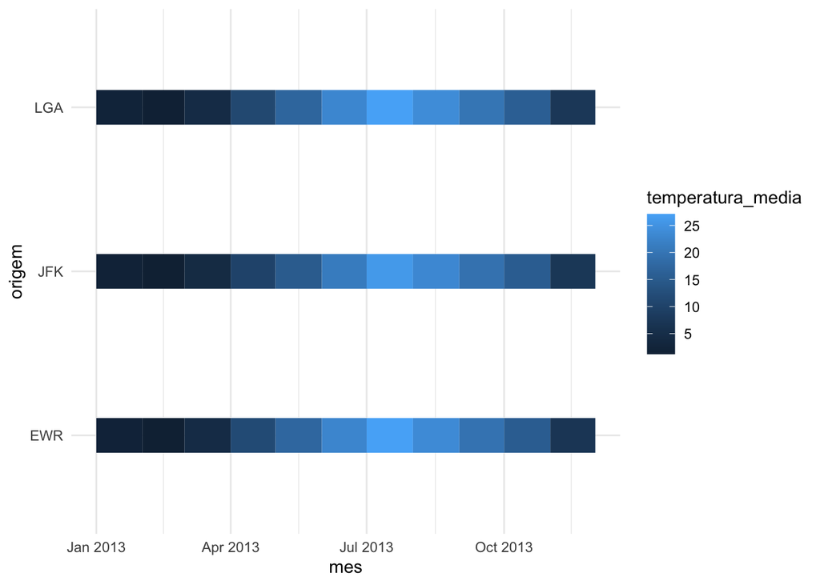

```r
temperatura_por_mes %>%
  ggplot() +
  geom_line(aes(x = mes, y = origem, color = temperatura_media), size = 10) +
  # theme_bw()
  # theme_classic()
  # theme_dark()
  theme_minimal()
```

- A função theme()

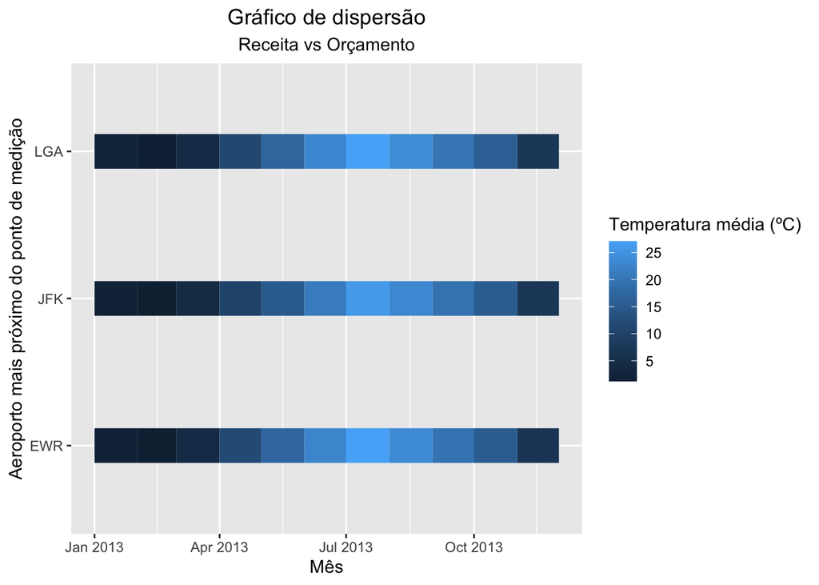

```r
temperatura_por_mes %>%
  ggplot() +
  geom_line(aes(x = mes, y = origem, color = temperatura_media), size = 10) +
  labs(
    title = "Gráfico de dispersão",
    subtitle = "Receita vs Orçamento",
    x = "Mês",
    y = "Aeroporto mais próximo do ponto de medição",
    color = "Temperatura média (ºC)"
  ) +
  theme(
    plot.title = element_text(hjust = 0.5),
    plot.subtitle = element_text(hjust = 0.5)
  )
```

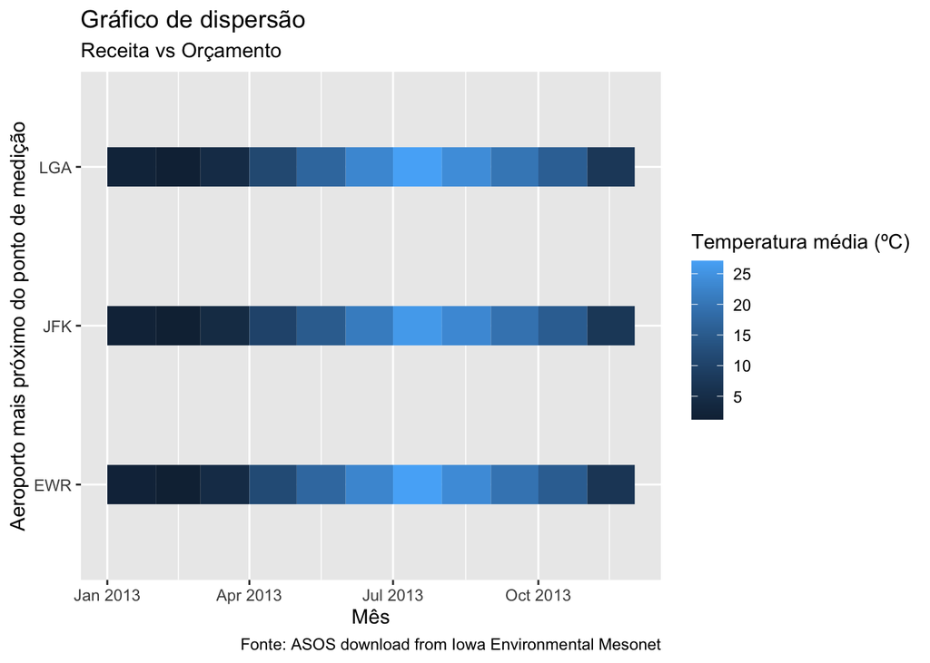

```r
grafico_base <- temperatura_por_mes %>%
  ggplot() +
  geom_line(aes(x = mes, y = origem, color = temperatura_media), size = 10) +
  labs(
    title = "Gráfico de dispersão",
    subtitle = "Receita vs Orçamento",
    x = "Mês",
    y = "Aeroporto mais próximo do ponto de medição",
    color = "Temperatura média (ºC)",
    caption = "Fonte: ASOS download from Iowa Environmental Mesonet"
  )

grafico_base
```

Vamos explorar os componentes mais importantes do theme!

- Esses componentes têm vários subcomponentes, que podem ser consultados em `help(theme)`
- O padrão dos nomes é, por exemplo, `theme(axis.text.x)`. Praticamente todos os componentes devem ser parametrizados como um:
  - 1. element_text, para componentes textuais como por exemplo axis.text.x , axis.text.y e legend.title. Exemplos:
- mudando o tamanho e a cor dos textos dos eixos

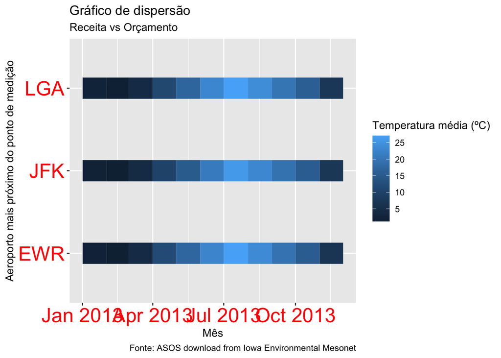

```r
grafico_base +
  theme(
    axis.text = element_text(color = 'red', size = 20)
  )
```

- mudando o tamanho e a cor do texto do título da legenda

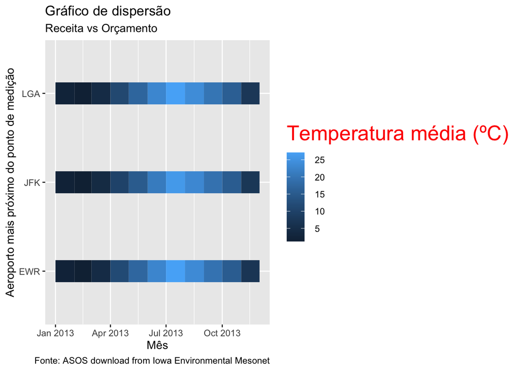

```r
grafico_base +
  theme(
    legend.title = element_text(color = 'red', size = 20)
  )
```

- mudando o tamanho e a cor do texto do texto da legenda

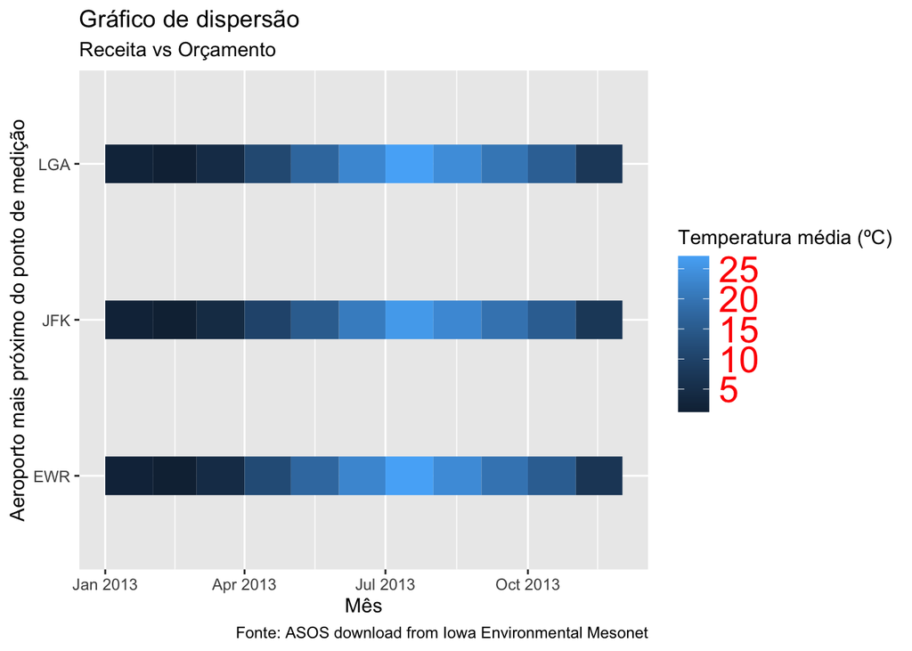

```r
grafico_base +
  theme(
    legend.text = element_text(color = 'red', size = 20)
  )
```

- 2. element_rect, para bordas e fundos, como panel.background. Exemplos:
- mudando a cor do fundo

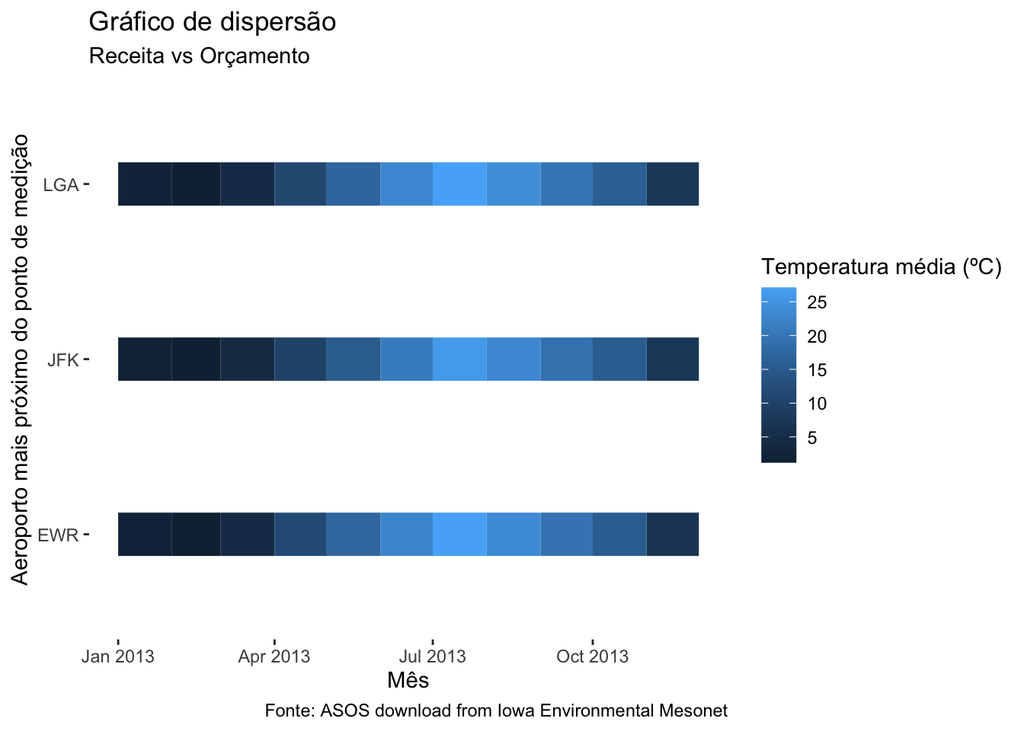

```r
grafico_base +
  theme(
    panel.background = element_rect(fill = 'white')
  )
```

- mudando a cor do fundo e as bordas

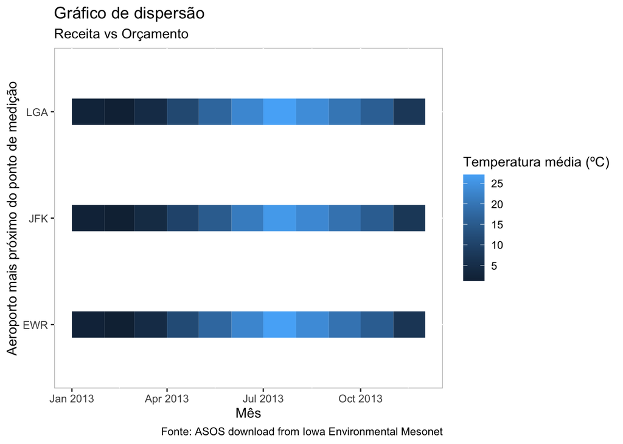

```r
grafico_base +
  theme(
    panel.background = element_rect(fill = 'white', color = 'gray')
  )
```

- mudando a cor do fundo, das bordas e aumentando o tamanho das bordas

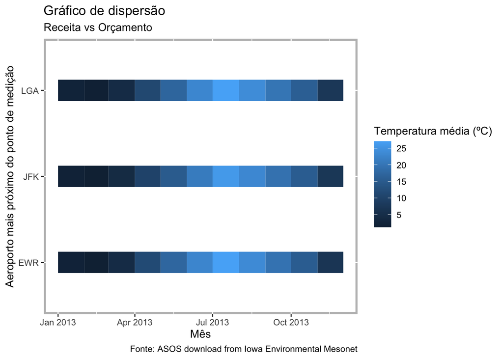

```r
grafico_base +
  theme(
    panel.background = element_rect(fill = 'white', color = 'gray', size = 2)
  )
```

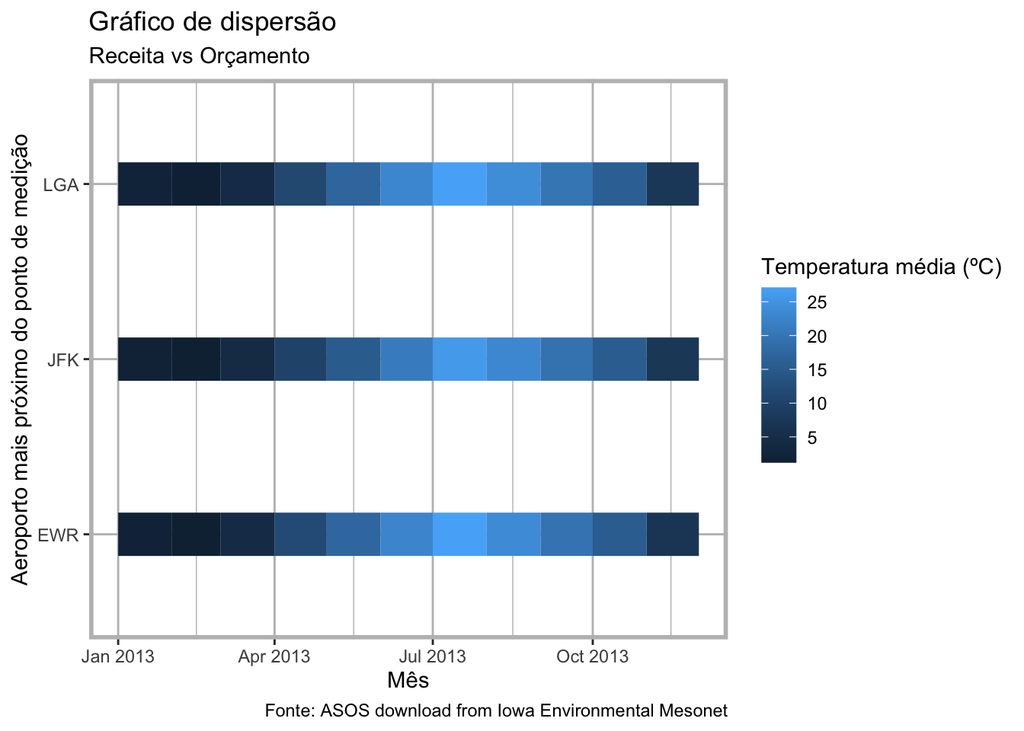

```r
grafico_base +
  theme(
    panel.background = element_rect(fill = 'white', color = 'gray', size = 2),
    panel.grid  = element_line(color = 'gray')
  )
```

- mudando a cor das linhas principais do eixo x

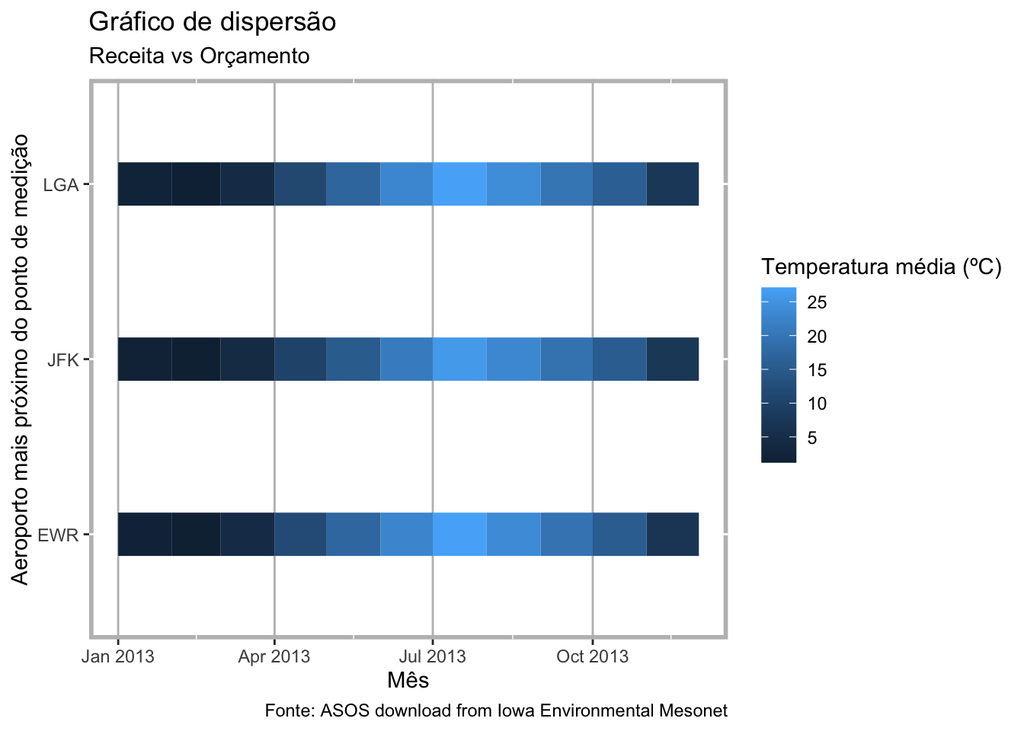

```r
grafico_base +
  theme(
    panel.background = element_rect(fill = 'white', color = 'gray', size = 2),
    panel.grid.major.x  = element_line(color = 'gray')
  )
```

- mudando a cor das linhas secundárias do eixo x

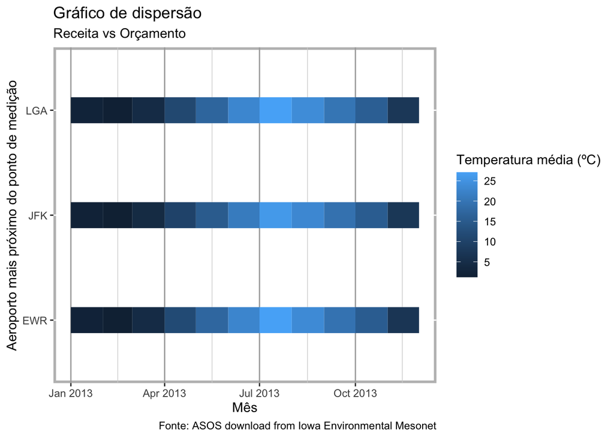

```r
grafico_base +
  theme(
    panel.background = element_rect(fill = 'white', color = 'gray', size = 2),
    panel.grid.major.x  = element_line(color = 'darkgray'),
    panel.grid.minor.x  = element_line(color = 'lightgray')
  )
```

- acabando com a diferença entre linhas major e minors

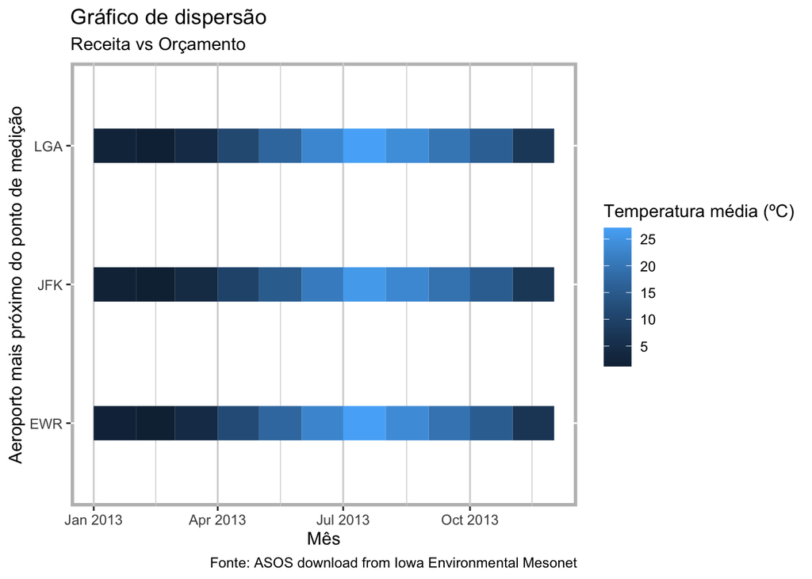

```r
grafico_base +
  theme(
    panel.background = element_rect(fill = 'white', color = 'gray', size = 2),
    panel.grid.major.x  = element_line(color = 'lightgray'),
    panel.grid.minor.x  = element_line(color = 'lightgray')
  )
```

## Mais temas

```r
#install.packages("ggthemes")
```

### Tema do fivethirthyeight

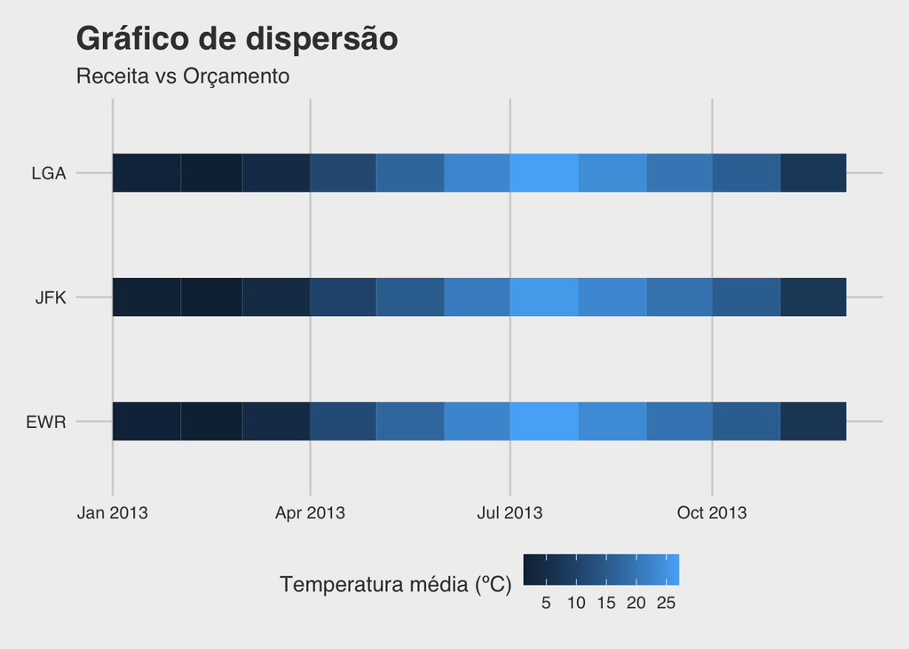

```r
temperatura_por_mes %>%
  ggplot() +
  geom_line(aes(x = mes, y = origem, color = temperatura_media), size = 10) +
  labs(
    title = "Gráfico de dispersão",
    subtitle = "Receita vs Orçamento",
    x = "Mês",
    y = "Aeroporto mais próximo do ponto de medição",
    color = "Temperatura média (ºC)"
  ) +
  ggthemes::theme_fivethirtyeight()
```

### Tema da Google Docs

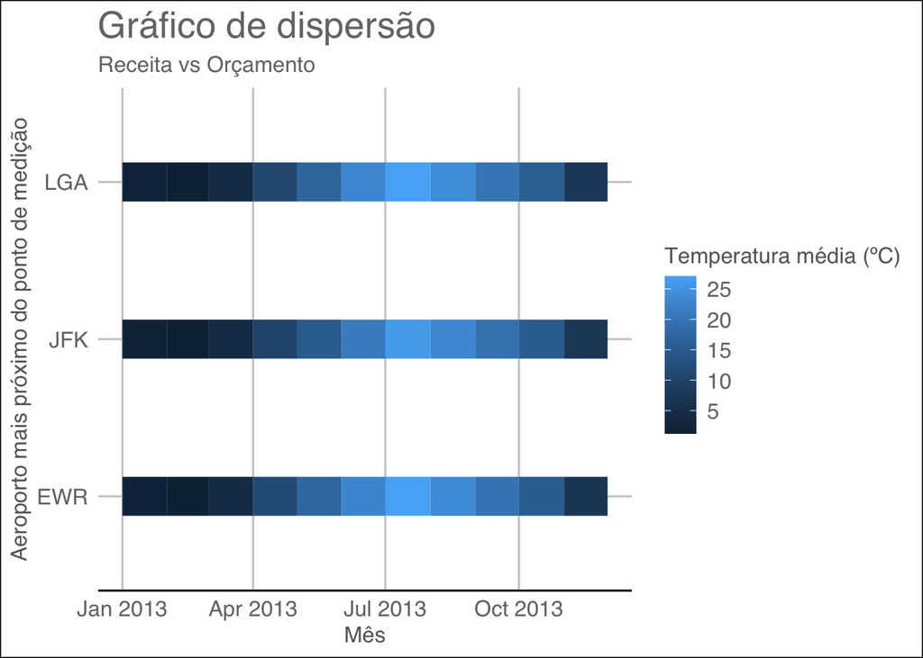

```r
temperatura_por_mes %>%
  ggplot() +
  geom_line(aes(x = mes, y = origem, color = temperatura_media), size = 10) +
  labs(
    title = "Gráfico de dispersão",
    subtitle = "Receita vs Orçamento",
    x = "Mês",
    y = "Aeroporto mais próximo do ponto de medição",
    color = "Temperatura média (ºC)"
  ) +
  ggthemes::theme_gdocs()
```

- Mais exemplos em: https://yutannihilation.github.io/allYourFigureAreBelongToUs/ggthemes/

## Cores

Existem muitas, muitas paletas de cores para serem usadas.

No {ggplot2}, temos já implementadas as paletas viridis e ColorBrewer. Vamos mostrar alguns exemplos de cada

### Viridis

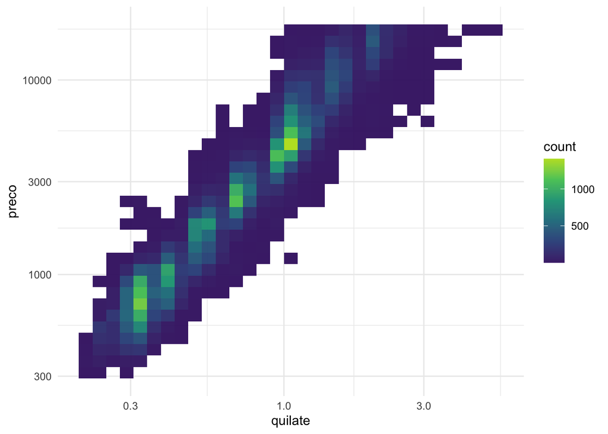

```r
ggplot(diamante, aes(quilate, preco)) +
  geom_bin2d() +
  # _c() vem de "continuo"
  scale_fill_viridis_c(
    alpha = .99,
    begin = .1,
    end = .9,
    direction = 1,
    option = "D"
  ) +
  scale_x_log10() +
  scale_y_log10() +
  theme_minimal()
```

- variaveis ordinais já vem em viridis

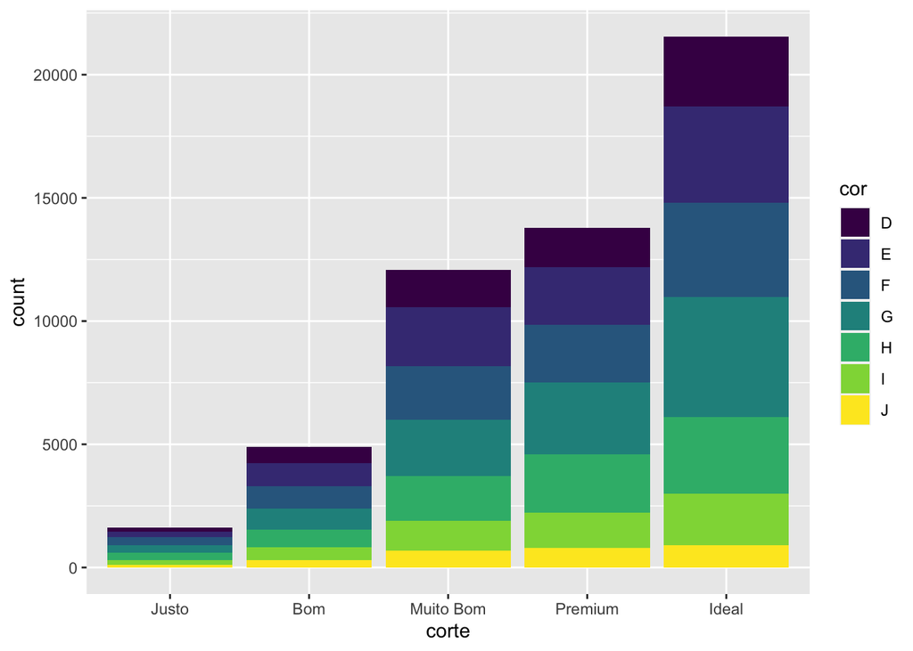

```r
diamante %>%
  ggplot(aes(corte, fill = cor)) +
  geom_bar()
```

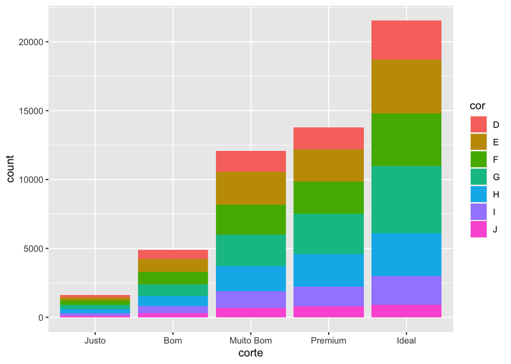

```r
diamante %>%
  dplyr::mutate(cor = factor(as.character(cor))) %>%
  ggplot(aes(corte, fill = cor)) +
  geom_bar()
```

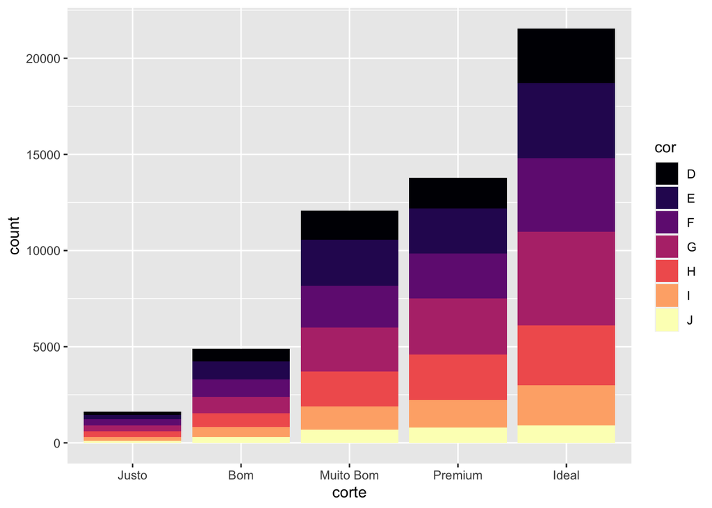

```r
diamante %>%
  dplyr::mutate(cor = factor(as.character(cor))) %>%
  ggplot(aes(corte, fill = cor)) +
  scale_fill_viridis_d(option = "A") +
  geom_bar()
```

```r
p_base <- diamante %>%
  ggplot(aes(corte, fill = cor)) +
  geom_bar() +
  theme_minimal()
```

### ColorBrewer

- sequencial

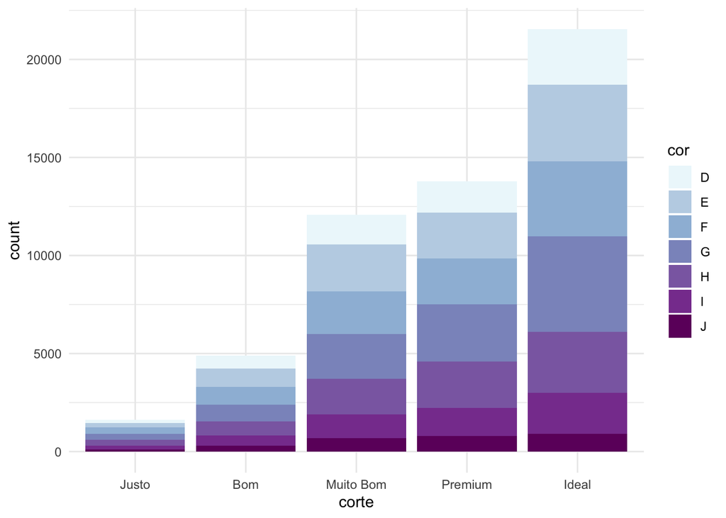

```r
p_base +
  scale_fill_brewer(palette = "BuPu")
```

- divergente

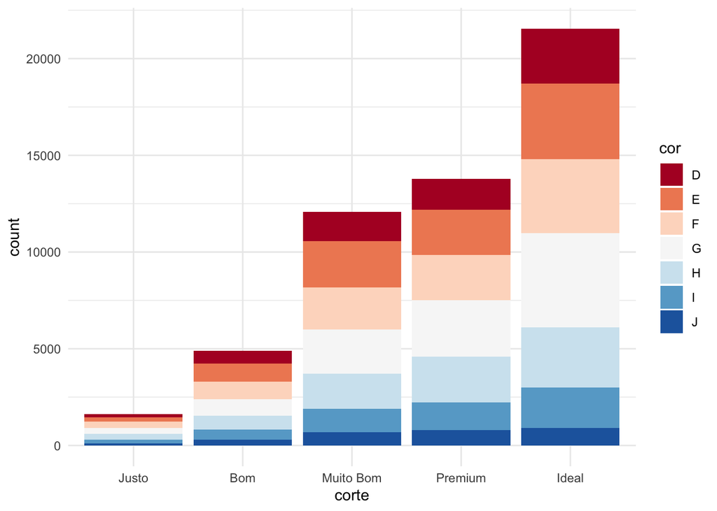

```r
p_base +
  scale_fill_brewer(palette = "RdBu")
```

- qualitativo

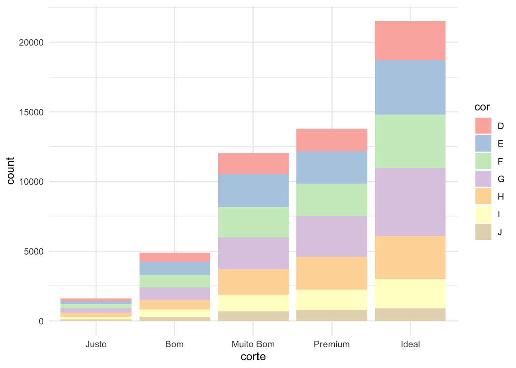

```r
p_base +
  scale_fill_brewer(palette = "Pastel1")
```

### scale_fill_brewer()

- usando brewer para variáveis contínuas: scale_fill_distiller() e scale_fill_fermenter()

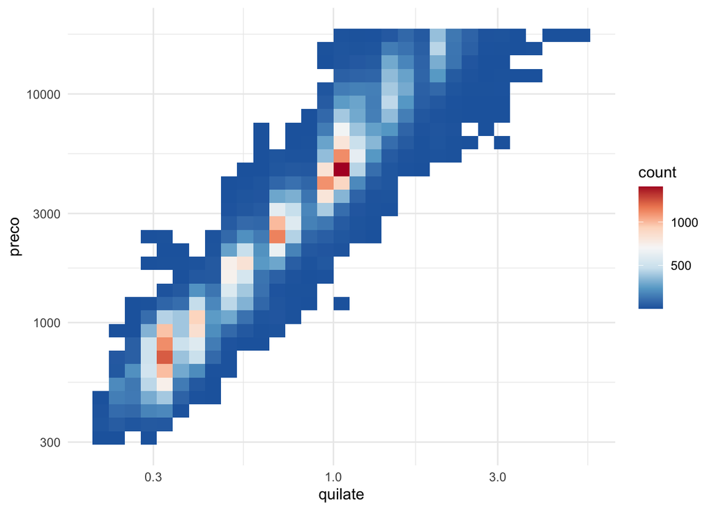

```r
ggplot(diamante, aes(quilate, preco)) +
  geom_bin2d() +
  scale_fill_distiller(palette = "RdBu") +
  scale_x_log10() +
  scale_y_log10() +
  theme_minimal()
```

- veja a diferença na legenda

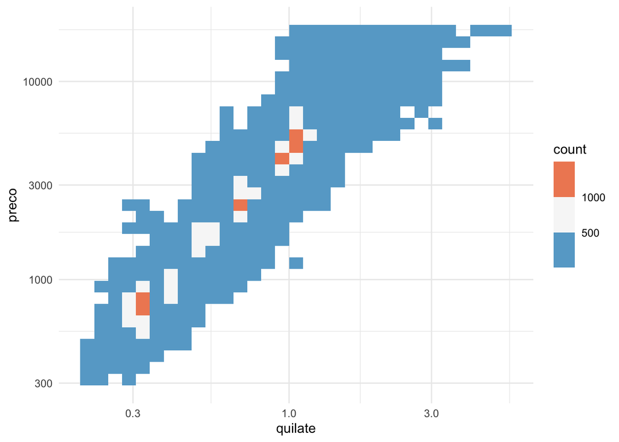

```r
ggplot(diamante, aes(quilate, preco)) +
  geom_bin2d() +
  scale_fill_fermenter(palette = "RdBu") +
  scale_x_log10() +
  scale_y_log10() +
  theme_minimal()
```

## Fazendo seu próprio esquema de cores

```r
# library(bslib)
# library(thematic)
#
# bs_theme_preview(
#   bs_theme(bg = "#444444", fg = "#E4E4E4", primary = "#E39777")
# )
```